# DATA 624 | Predictive Analytics

Gabriella Martinez

3/4/2022

# Homework 5: Exponential Smoothing

## Instructions

Do exercises 8.1, 8.5, 8.6, 8.7, 8.8, 8.9 in [Forecasting: Principles and Practice](https://otexts.com/fpp3/). Please submit both your Rpubs link as well as attach the .rmd file with your code.

## Packages

```r
library(fpp3)
```

## Exercises

### 8.1

Consider the the number of pigs slaughtered in Victoria, available in the `aus_livestock` dataset.

1. Use the ETS() function to estimate the equivalent model for simple exponential smoothing. Find the optimal values of $\alpha$ and $\ell_0$, and generate forecasts for the next four months.

```r
#filter data and preview it
vic_pigs <- aus_livestock %>%
  filter(State=='Victoria', Animal=='Pigs') %>%
  summarise(Count = sum(Count/1e3))

head(vic_pigs)
```

```
## # A tsibble: 6 x 2 [1M]
##      Month Count
##      <mth> <dbl>
## 1 1972 Jul  94.2
## 2 1972 Aug 106.
## 3 1972 Sep  96.5
## 4 1972 Oct 117.
## 5 1972 Nov 105.
## 6 1972 Dec 100.
```

```r
tail(vic_pigs)
```

```
## # A tsibble: 6 x 2 [1M]
##      Month Count
##      <mth> <dbl>
## 1 2018 Jul 101.
## 2 2018 Aug 102.
## 3 2018 Sep  82.6
## 4 2018 Oct 101.
## 5 2018 Nov  98.5
## 6 2018 Dec  92.3
```

```r
#
fit <- vic_pigs %>%
  model(
    SES = ETS(Count ~ error("A") + trend("N") + season("N"))
  )

report(fit)
```

```
## Series: Count
## Model: ETS(A,N,N)
##   Smoothing parameters:
##     alpha = 0.3219175
##
##   Initial states:
##      l[0]
##  100.4949
##
##   sigma^2:  87.4807
##
##      AIC     AICc      BIC
## 6028.040 6028.084 6041.013
```

$\alpha$ = 0.3219  
$\ell$ = 100.4949

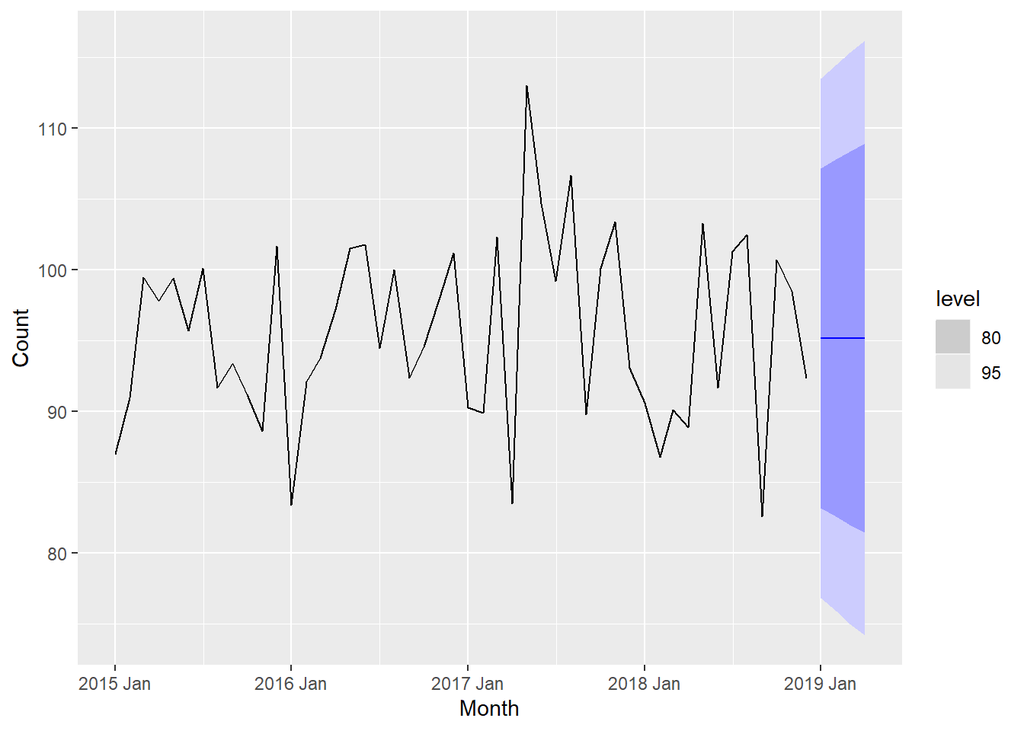

```r
#filter Month to see the forecast better
filterplot <- vic_pigs %>% filter(year(Month)>= 2015)

fit %>%
  forecast(h = 4) %>%
  autoplot(filterplot)
```

2. Compute a 95% prediction interval for the first forecast using $\hat{y} \pm 1.96s$ where $s$ is the standard deviation of the residuals. Compare your interval with the interval produced by R.

Multiplier for 95% prediction interval, $c$: 1.96

```r
#four month forecast
fc <-fit %>% forecast(h = 4)
```

Computed 95% prediction interval

```r
#get the mean
y_hat <- fc$.mean[1]

#get the residuals
aug_fit <- augment(fit)

#get standard dev using residuals
s <- sd(aug_fit$.resid)

# Calculate the 95% prediction intervals
upper_95 <- y_hat + (s * 1.96)
lower_95 <- y_hat - (s * 1.96)


#lower interval
lower_95
```

```
## [1] 76.87131
```

```r
#upper interval
upper_95
```

```
## [1] 113.5024
```

R generated 95% prediction interval

```r
# Determine the model forecast 95% intervals
fc_hilo <- fc %>% hilo()

# Output model interval values
fc_hilo$`95%`[1]
```

```
## <hilo[1]>
## [1] [76.85509, 113.5186]95
```

While the two intervals are similar to the first decimal place (without rounding), they are not identical beyond that. The variance of the residuals generated using R use a more accurate critical value than the 1.96 used in our manual calculation in addition to degrees of freedom being taken into account in the R generated interval.

### 8.5

Data set global_economy contains the annual Exports from many countries. Select one country to analyse.

```r
us_econ <- global_economy %>%
  filter(Country == 'United States')

#sum(is.na(us_econ))

us_econ <- na.omit(us_econ)
```

1. Plot the Exports series and discuss the main features of the data.

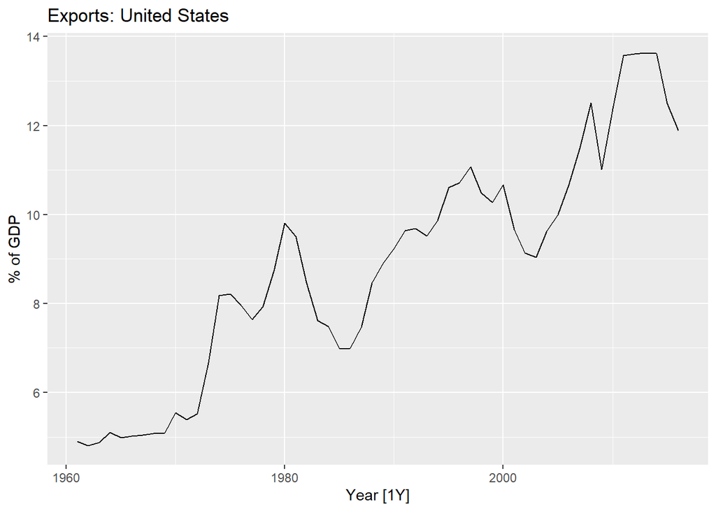

```r
us_econ %>% autoplot(Exports)+
  labs(y = "% of GDP", title = "Exports: United States")
```

2. Use an ETS(A,N,N) model to forecast the series, and plot the forecasts.

```r
# Estimate parameters
fit <- us_econ %>%
  model(ETS(Exports ~ error("A") + trend("N") + season("N")))

#create the forecast
fc <- fit %>%
  forecast(h = 5)
```

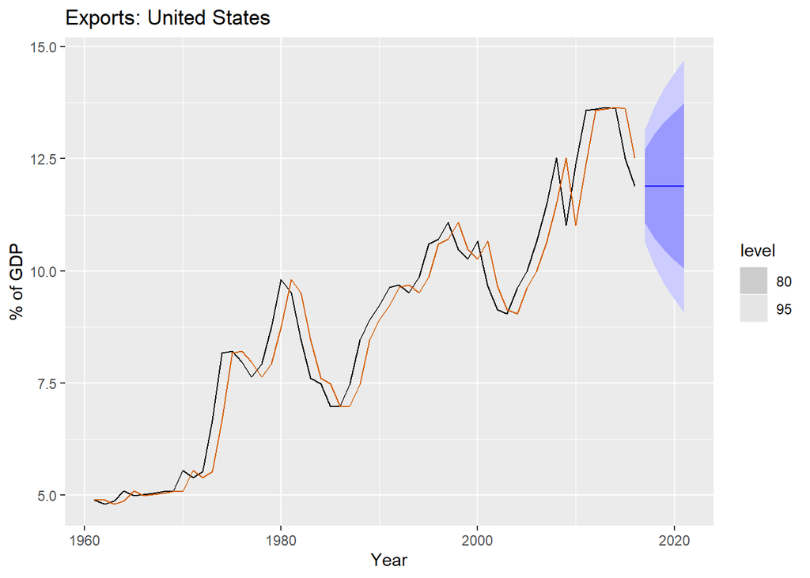

```r
fc %>%
  autoplot(us_econ) +
  geom_line(aes(y = .fitted), col="#D55E00",
            data = augment(fit)) +
  labs(y="% of GDP", title="Exports: United States") +
  guides(colour = "none")
```

3. Compute the RMSE values for the training data.

```r
fit %>% accuracy()
```

```
## # A tibble: 1 x 11
##   Country       .model     .type    ME  RMSE   MAE   MPE  MAPE  MASE RMSSE  ACF1
##   <fct>         <chr>      <chr> <dbl> <dbl> <dbl> <dbl> <dbl> <dbl> <dbl> <dbl>
## 1 United States "ETS(Expo~ Trai~ 0.125 0.632 0.468  1.35  5.09 0.982 0.991 0.239
```

4. Compare the results to those from an ETS(A,A,N) model. (Remember that the trended model is using one more parameter than the simpler model.) Discuss the merits of the two forecasting methods for this data set.

```r
fit_compare <- us_econ %>%
  model(
    ANN = ETS (Exports ~ error("A") + trend("N") + season("N")),
    AAN = ETS (Exports ~ error("A") + trend("A") + season("N"))
    )
accuracy(fit_compare)
```

```
## # A tibble: 2 x 11
##   Country       .model .type       ME  RMSE   MAE    MPE  MAPE  MASE RMSSE  ACF1
##   <fct>         <chr>  <chr>    <dbl> <dbl> <dbl>  <dbl> <dbl> <dbl> <dbl> <dbl>
## 1 United States ANN    Train~ 0.125   0.632 0.468  1.35   5.09 0.982 0.991 0.239
## 2 United States AAN    Train~ 0.00170 0.621 0.476 -0.123  5.30 0.997 0.974 0.233
```

Using the RMSE to compare the models, the AAN model provides a smaller RMSE value than that of the ANN model suggesting AAN is the better performing model of the two. The AAN performed better by approximately 0.011 over the ANN.

5. Compare the forecasts from both methods. Which do you think is best?

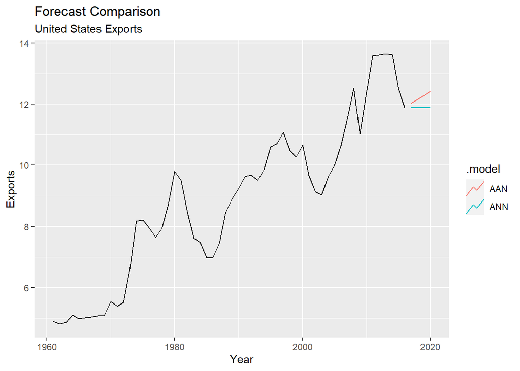

```r
fit_compare %>%
  forecast(h=4) %>%
  autoplot(us_econ, level=NULL) +
  labs(title="Forecast Comparison",
       subtitle = "United States Exports")
```

6. Calculate a 95% prediction interval for the first forecast for each model, using the RMSE values and assuming normal errors. Compare your intervals with those produced using R.

Calculated 95% prediction interval

```r
#get the mean
y_hat <- fc$.mean[1]

#get the residuals
aug_fit <- augment(fit)

#get standard dev using residuals
s <- sd(aug_fit$.resid)

# Calculate the 95% prediction intervals
upper_95 <- y_hat + (s * 1.96)
lower_95 <- y_hat - (s * 1.96)

#lower interval
lower_95
```

```
## [1] 10.66541
```

```r
#upper interval
upper_95
```

```
## [1] 13.11596
```

R generated 95% prediction interval

```r
# Determine the model forecast 95% intervals
fc_hilo <- fc %>% hilo()

# Output model interval values
fc_hilo$`95%`[1]
```

```
## <hilo[1]>
## [1] [10.62928, 13.15209]95
```

While the two intervals are similar to the first decimal place (without rounding), they are not identical beyond that. The variance of the residuals generated using R use a more accurate critical value than the 1.96 used in our manual calculation in addition to degrees of freedom being taken into account in the R generated interval.

### 8.6

Forecast the Chinese GDP from the `global_economy` data set using an ETS model. Experiment with the various options in the `ETS()` function to see how much the forecasts change with damped trend, or with a Box-Cox transformation. Try to develop an intuition of what each is doing to the forecasts.

[Hint: use a relatively large value of `h` when forecasting, so you can clearly see the differences between the various options when plotting the forecasts.]

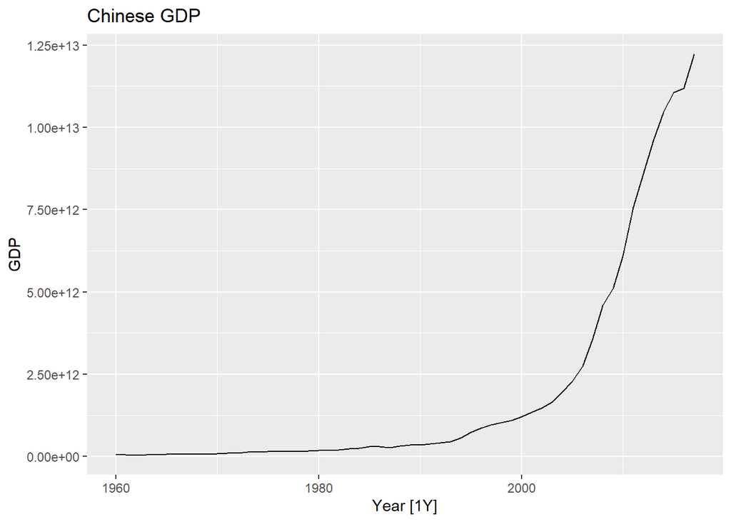

```r
china <- global_economy %>%
  filter(Country == "China")

china %>% autoplot(GDP) +
  labs(title="Chinese GDP")
```

The Chinese GDP data shows a strong upward trend, with no evidence of a cycle or season. The activity resembles that of exponential growth. GDP is almost stagnant from the year 1960 up until what looks like the mid 1990s and then shows an incredible increase from there on wards with a minor stagnant point around 2015.

A Box-Cox transformation may be beneficial in eliminating the non-constant variance shown in the Chinese GDP data.

```r
#obtain optimal lambda for BoxCox transform
lambda <- china %>%
  features(GDP, features = guerrero) %>%
  pull(lambda_guerrero)
```

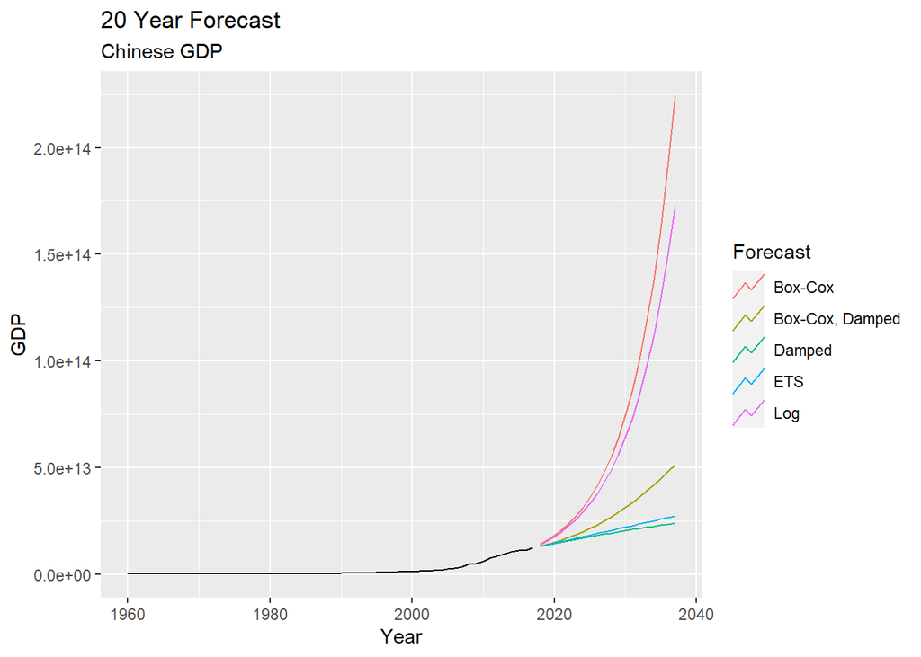

```r
fit <- china %>%
  model(
    # ETS
    ETS = ETS(GDP),
    # Log Transformation
    `Log` = ETS(log(GDP)),
    # Damped Model
    `Damped` = ETS(GDP ~ trend("Ad")),
    # Box-Cox Transformation
    `Box-Cox` = ETS(box_cox(GDP, lambda)),
    # Damped Model w Box-Cox Transformation
    `Box-Cox, Damped` = ETS(box_cox(GDP, lambda) ~ trend("Ad"))
)

fit %>%
  forecast(h="20 years") %>%
  autoplot(china, level = NULL)+
  labs(title="20 Year Forecast",
       subtitle= "Chinese GDP") +
  guides(colour = guide_legend(title = "Forecast"))
```

Based on the plot, our Box-Cox and Log transformed forecast appear slightly to over-forecast for the Chinese GDP data. The generic ETS model falls between our damped models which are simple damped model of the ETS, and a Box-Cox with dampening. The dampened forecast plots exhibit slower growth than the transformed forecasts where the transformed forecasts resemble continued exponential growth.

### 8.7

Find an ETS model for the Gas data from `aus_production` and forecast the next few years. Why is multiplicative seasonality necessary here? Experiment with making the trend damped. Does it improve the forecasts?

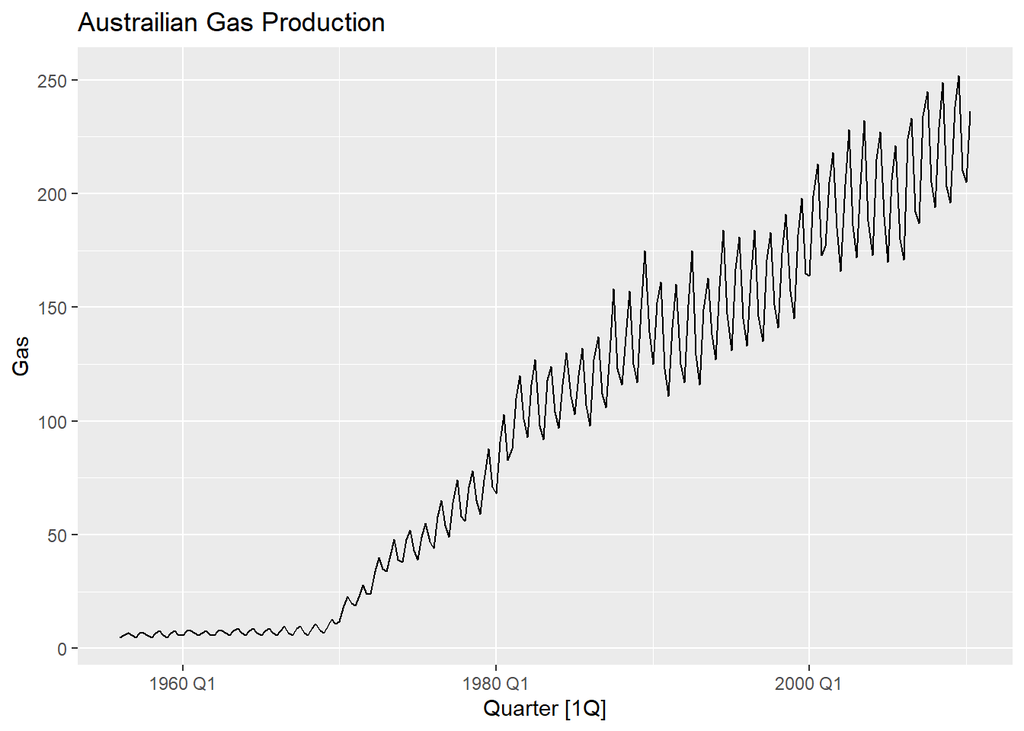

```r
aus_production %>% autoplot(Gas)+
  labs(title="Austrailian Gas Production")
```

Multiplicative seasonality is needed in this case because there is seasonal variation that increases with time.

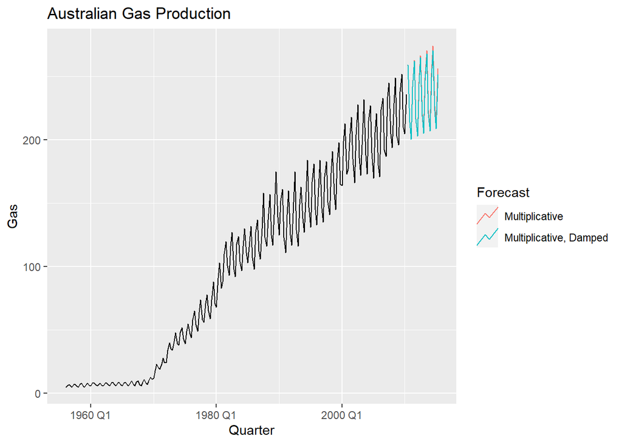

```r
fit <- aus_production %>%
  model(
    # Multiplicative
    Multiplicative = ETS(Gas ~ error("M") + trend("A") + season("M")),
    # Damped multiplicative
    `Multiplicative, Damped` = ETS(Gas ~ error("M") + trend("Ad") + season("M"))
  )
fc <- fit %>% forecast(h = "5 years")

fc %>%
  autoplot(aus_production, level = NULL) +
  labs(title="Australian Gas Production") +
  guides(colour = guide_legend(title = "Forecast"))
```

```r
report(fit)
```

```
## # A tibble: 2 x 9
##   .model                  sigma2 log_lik   AIC  AICc   BIC   MSE  AMSE    MAE
##   <chr>                    <dbl>   <dbl> <dbl> <dbl> <dbl> <dbl> <dbl>  <dbl>
## 1 Multiplicative         0.00324   -831. 1681. 1682. 1711.  21.1  32.2 0.0413
## 2 Multiplicative, Damped 0.00329   -832. 1684. 1685. 1718.  21.1  32.0 0.0417
```

Based on the AIC values derived from the `report()` of our `fit` as well as our plot, there doesn’t seem to be much difference between the damped and un-damped forecast. Both produce about the same results, with very small difference in their AIC values where the un-damped forecast performs slightly better than the damped by 3.09909.

### 8.8

Recall your retail time series data (from Exercise 8 in Section [2.10](https://otexts.com/fpp3/graphics-exercises.html#graphics-exercises)).

```r
set.seed(555)

myseries <- aus_retail %>%
  filter(`Series ID` == sample(aus_retail$`Series ID`,1))

myseries
```

```
## # A tsibble: 441 x 5 [1M]
## # Key:       State, Industry [1]
##    State             Industry          `Series ID`    Month Turnover
##    <chr>             <chr>             <chr>          <mth>    <dbl>
##  1 Western Australia Department stores A3349434X   1982 Apr     36.5
##  2 Western Australia Department stores A3349434X   1982 May     43.7
##  3 Western Australia Department stores A3349434X   1982 Jun     38
##  4 Western Australia Department stores A3349434X   1982 Jul     42
##  5 Western Australia Department stores A3349434X   1982 Aug     38.5
##  6 Western Australia Department stores A3349434X   1982 Sep     40.2
##  7 Western Australia Department stores A3349434X   1982 Oct     37.4
##  8 Western Australia Department stores A3349434X   1982 Nov     42.4
##  9 Western Australia Department stores A3349434X   1982 Dec     71.9
## 10 Western Australia Department stores A3349434X   1983 Jan     35.6
## # ... with 431 more rows
```

1. Why is multiplicative seasonality necessary for this series?

2. Apply Holt-Winters’ multiplicative method to the data. Experiment with making the trend damped.

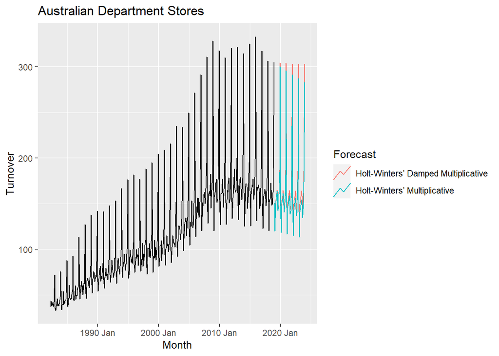

```r
fit <- myseries %>%
  model(
    `Holt-Winters’ Multiplicative` = ETS(Turnover ~ error("M") + trend("A") +
                                                season("M")),
    `Holt-Winters’ Damped Multiplicative` = ETS(Turnover ~ error("M") + trend("Ad") +
                                                season("M"))
  )
fc <- fit %>% forecast(h = "5 years")
fc %>%
  autoplot(myseries, level = NULL) +
  labs(title="Australian Department Stores",
       y="Turnover") +
  guides(colour = guide_legend(title = "Forecast"))
```

3. Compare the RMSE of the one-step forecasts from the two methods. Which do you prefer?

```r
accuracy(fit) %>%select(".model", "RMSE")
```

```
## # A tibble: 2 x 2
##   .model                               RMSE
##   <chr>                               <dbl>
## 1 Holt-Winters’ Multiplicative         5.53
## 2 Holt-Winters’ Damped Multiplicative  5.53
```

Comapring the Holt-Winters’ Multiplicative to the Holt-Winters’ Damped Multiplicative for the Department Store data, both produce approximately the same results. The plots of both forecasts are nearly identical and their RMSE values have a difference of 0.002167. While both are nearly identical, the model with the least RMSE value is that of the Holt-Winters’ Damped Multiplicative method.

4. Check that the residuals from the best method look like white noise.

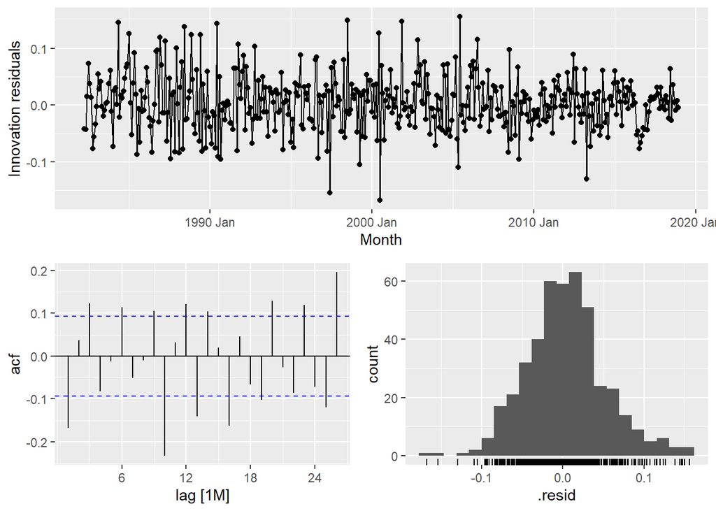

```r
fit %>% select("Holt-Winters’ Damped Multiplicative") %>% gg_tsresiduals()
```

Using the ACF plot, it shows that the Holt-Winters’ Damped Multiplicative method is not white noise, because more than 5% of the spikes are outside of the dashed lines.

5. Now find the test set RMSE, while training the model to the end of 2010. Can you beat the seasonal naïve approach from Exercise 7 in Section [5.11](https://otexts.com/fpp3/toolbox-exercises.html#toolbox-exercises)?

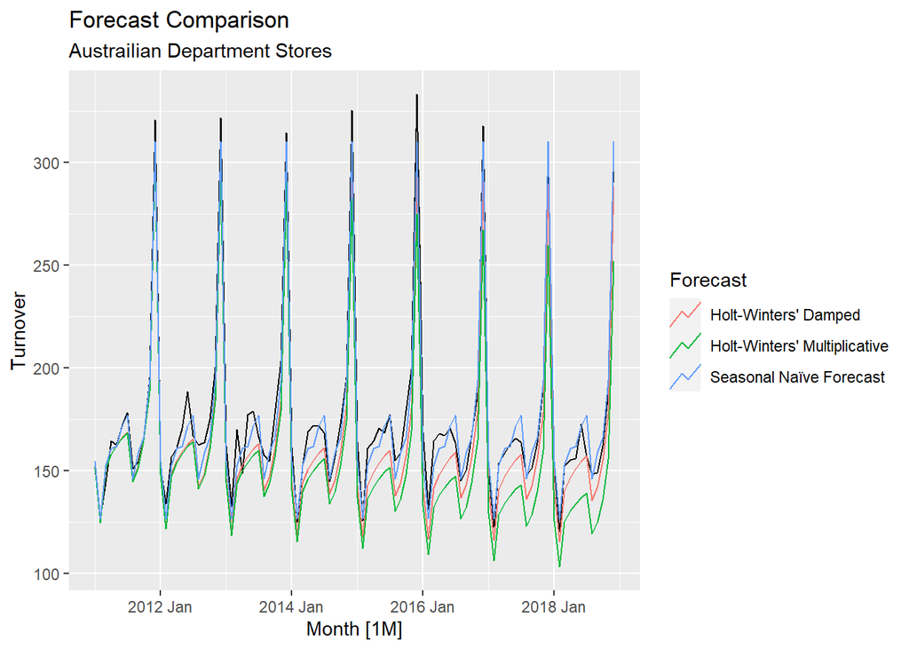

```r
# split
myseries_train <- myseries %>%
  filter(year(Month) < 2011)

# seasonal naïve
fit <- myseries_train %>%
  model(
    "Holt-Winters' Damped" = ETS(Turnover ~ error("M") + trend("Ad") +
                                            season("M")),
    "Holt-Winters' Multiplicative" = ETS(Turnover ~ error("M") + trend("A") +
                                                    season("M")),
    "Seasonal Naïve Forecast" = SNAIVE(Turnover)
  )


comparison <- anti_join(myseries, myseries_train,
                     by = c("State", "Industry", "Series ID", "Month", "Turnover"))

# Do the forecasting according to comparison data
fc <- fit %>%
      forecast(comparison)

# plot
autoplot(comparison, Turnover) +
  autolayer(fc, level = NULL) +
  guides(colour=guide_legend(title="Forecast")) +
  ggtitle('Forecast Comparison',
          subtitle= "Austrailian Department Stores")
```

```r
accuracy(fit)
```

```
## # A tibble: 3 x 12
##   State       Industry .model .type      ME  RMSE   MAE    MPE  MAPE  MASE RMSSE
##   <chr>       <chr>    <chr>  <chr>   <dbl> <dbl> <dbl>  <dbl> <dbl> <dbl> <dbl>
## 1 Western Au~ Departm~ Holt-~ Trai~  0.255   5.29  3.91  0.188  4.00 0.625 0.653
## 2 Western Au~ Departm~ Holt-~ Trai~ -0.0964  5.33  3.95 -0.152  4.04 0.630 0.657
## 3 Western Au~ Departm~ Seaso~ Trai~  4.76    8.10  6.26  4.82   6.25 1     1
## # ... with 1 more variable: ACF1 <dbl>
```

### 8.9

For the same retail data, try an STL decomposition applied to the Box-Cox transformed series, followed by ETS on the seasonally adjusted data. How does that compare with your best previous forecasts on the test set?

```r
#find optimal lambda
lambda <- myseries_train %>%
  features(Turnover, features = guerrero) %>%
  pull(lambda_guerrero)

#bc transformed data
ts_bc <- myseries_train %>%
  mutate(
    bc_turnover = box_cox(Turnover, lambda)
  )

# bc transformed model
fit <- ts_bc %>%
  model(
    'Box-Cox STL' = STL(bc_turnover ~ season(window = "periodic"),
             robust = T),
    'Box-Cox ETS' = ETS(bc_turnover)
  )

# best previous model
best_fit <-ts_bc %>%
  model(
    "Holt-Winters' Damped" = ETS(Turnover ~ error("M") + trend("Ad") +
                                                    season("M"))
  )

rbind(accuracy(fit),accuracy(best_fit))
```

```
## # A tibble: 3 x 12
##   State   Industry .model .type       ME   RMSE    MAE     MPE  MAPE  MASE RMSSE
##   <chr>   <chr>    <chr>  <chr>    <dbl>  <dbl>  <dbl>   <dbl> <dbl> <dbl> <dbl>
## 1 Wester~ Departm~ Box-C~ Trai~ -9.96e-4 0.0483 0.0360 -0.0362 0.822 0.557 0.595
## 2 Wester~ Departm~ Box-C~ Trai~  3.43e-3 0.0517 0.0399  0.0726 0.901 0.616 0.637
## 3 Wester~ Departm~ Holt-~ Trai~  2.55e-1 5.29   3.91    0.188  4.00  0.625 0.653
## # ... with 1 more variable: ACF1 <dbl>
```

Based on the RMSE values, the Box-Cox STL model is the best performing out of the three with an RMSE of 0.048.